# Getting Started: Market Research

This Jupyter notebook is a quick demonstration on how to get started on the market research section.

## 1) Download Data

Please download the train and test data and place it within the ./research/data path. If you've placed it in the correct place, you should see the following cell work:

```python
import pandas as pd
import numpy as np

train_data = pd.read_csv('./data/train.csv')
test_data = pd.read_csv('./data/test.csv')
train_new = pd.read_csv('./data/train_new.csv')
test_new = pd.read_csv('./data/test_new.csv')

train_data = pd.concat([train_data, train_new])
test_data = pd.concat([test_data, test_new])


# print(train_data.head())
# print(test_data.head())
print(test_data.columns)
# n = len(pd.unique(train_data['O']))
# print(n)

train_data = train_data.replace([np.nan, -np.inf], 0)
print(train_data.head())

test_data = train_data.replace([np.nan, -np.inf], 0)
print(test_data.head())
```

```
Index(['id', 'time', 'A', 'B', 'C', 'D', 'E', 'F', 'G', 'H', 'I', 'J', 'K',
       'L', 'M', 'N', 'O', 'P'],
      dtype='object')
   time         A         B         C         D         E         F         G  \
0   0.0  0.207366 -0.159951 -0.634176 -0.580962 -0.266505  0.060173 -0.475257
1   1.0  0.188828 -0.265508  0.042143 -0.550442 -0.132319 -0.185219  0.028295
2   2.0 -0.144261 -0.577142 -0.214634 -0.747391 -0.184255 -0.464831 -0.085181
3   3.0  0.208982 -0.310449  0.513708 -0.562868  0.742308 -0.305487  0.762246
4   4.0  0.093320 -0.358156  0.173188 -0.687296 -0.161461 -0.116062 -0.245748

          H         I         J         K         L         M         N  \
0 -1.486516 -0.332594 -0.671466 -0.226149 -0.187624 -0.780237 -0.785965
1  0.093210 -0.518139 -0.251917 -0.347845 -0.359069 -0.161254  0.020401
2  0.700449 -0.603438  0.197773 -0.566696 -0.580799  0.202726  0.135261
3  1.363020 -0.384575  0.525556 -0.348514 -0.428099  0.548993  0.471031
4  0.863372 -0.655588 -0.263358 -0.557428 -0.481214  0.083602  0.003087

         Y1        Y2    O    P
0 -0.935902 -0.310081  0.0  0.0
1 -0.089707 -0.305374  0.0  0.0
2 -0.077855 -0.631485  0.0  0.0
3  0.941271 -0.535212  0.0  0.0
4 -0.039582 -0.490561  0.0  0.0
   time         A         B         C         D         E         F         G  \
0   0.0  0.207366 -0.159951 -0.634176 -0.580962 -0.266505  0.060173 -0.475257
1   1.0  0.188828 -0.265508  0.042143 -0.550442 -0.132319 -0.185219  0.028295
2   2.0 -0.144261 -0.577142 -0.214634 -0.747391 -0.184255 -0.464831 -0.085181
3   3.0  0.208982 -0.310449  0.513708 -0.562868  0.742308 -0.305487  0.762246
4   4.0  0.093320 -0.358156  0.173188 -0.687296 -0.161461 -0.116062 -0.245748

          H         I         J         K         L         M         N  \
0 -1.486516 -0.332594 -0.671466 -0.226149 -0.187624 -0.780237 -0.785965
1  0.093210 -0.518139 -0.251917 -0.347845 -0.359069 -0.161254  0.020401
2  0.700449 -0.603438  0.197773 -0.566696 -0.580799  0.202726  0.135261
3  1.363020 -0.384575  0.525556 -0.348514 -0.428099  0.548993  0.471031
4  0.863372 -0.655588 -0.263358 -0.557428 -0.481214  0.083602  0.003087

         Y1        Y2    O    P
0 -0.935902 -0.310081  0.0  0.0
1 -0.089707 -0.305374  0.0  0.0
2 -0.077855 -0.631485  0.0  0.0
3  0.941271 -0.535212  0.0  0.0
4 -0.039582 -0.490561  0.0  0.0
```

## 2) Investigate the Dataset

Let's do some exploration of the relationships of A - N and Y1. In particular, let's look at the relationship between C and Y1:

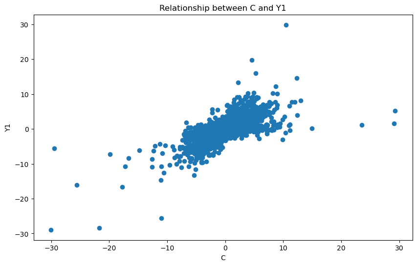

```python
import matplotlib.pyplot as plt

plt.figure(figsize=(10, 6))
plt.scatter(train_data['C'], train_data['Y1'])
plt.xlabel('C')
plt.ylabel('Y1')
plt.title('Relationship between C and Y1')
plt.show()
```

```python
# Calculate correlation between C and Y1
correlation = train_data['C'].corr(train_data['Y1'])
print(f"Correlation between C and Y1: {correlation:.4f}")
```

```
Correlation between C and Y1: 0.7038
```

Clearly there's a strong relationship between C and Y1. You should definitely use C to predict Y1!

```python
# check the types of Y1 and Y2
import matplotlib.pyplot as plt
import numpy as np

train_data[["Y1", "Y2"]].dtypes
train_data[["Y1", "Y2"]].nunique()
print(train_data[["Y1","Y2"]].value_counts().head(10))
```

```
Y1          Y2
 0.000000    0.000000     80000
-28.918180   29.957171        1
 0.242211   -0.213660         1
 0.242192   -0.614452         1
 0.242187   -0.242559         1
 0.242158   -0.263477         1
 0.242157   -0.524843         1
 0.242141   -0.422102         1
 0.242098   -0.582158         1
 0.242079    0.233688         1
Name: count, dtype: int64
```

```python
%pip install graphviz
# Modelling
from sklearn.multioutput import MultiOutputRegressor
from sklearn.ensemble import RandomForestRegressor
from sklearn.metrics import accuracy_score, confusion_matrix, precision_score, recall_score, ConfusionMatrixDisplay
from sklearn.model_selection import RandomizedSearchCV, train_test_split
from scipy.stats import randint

# Tree Visualisation
from sklearn.tree import export_graphviz
from IPython.display import Image
import graphviz
```

```python
from sklearn.model_selection import train_test_split

# Features (drop targets)
X = train_data.drop(columns=["Y1", "Y2", "time"])
X = X.dropna()
print(X.columns)

# Targets
y1 = train_data["Y1"]
y2 = train_data["Y2"]

# Split 80:20
X_train, X_test, y1_train, y1_test = train_test_split(
    X, y1, test_size=0.2, random_state=42
)
_, _, y2_train, y2_test = train_test_split(
    X, y2, test_size=0.2, random_state=42
)

print("X_train shape:", X_train.shape)
print("X_test shape:", X_test.shape)
print("y1_train shape:", y1_train.shape)
print("y1_test shape:", y1_test.shape)
print("y2_train shape:", y2_train.shape)
print("y2_test shape:", y2_test.shape)
```

```
Index(['A', 'B', 'C', 'D', 'E', 'F', 'G', 'H', 'I', 'J', 'K', 'L', 'M', 'N',
       'O', 'P'],
      dtype='object')
X_train shape: (128000, 16)
X_test shape: (32000, 16)
y1_train shape: (128000,)
y1_test shape: (32000,)
y2_train shape: (128000,)
y2_test shape: (32000,)
```

```python
rf = RandomForestRegressor()
rf.fit(X_train, y1_train)
```

```
RandomForestRegressor()
```

```python
yf = RandomForestRegressor()
yf.fit(X_train, y2_train)
```

```
RandomForestRegressor()
```

```python
test_data = pd.read_csv('./data/test.csv')
test_new = pd.read_csv('./data/test_new.csv')
test_data = pd.concat([test_data, test_new])
print(test_data.columns)

test_copy = test_data
X_1 = test_copy.drop(columns=["id", "time"])
y1_pred = rf.predict(X_test)
y1_pred_test = rf.predict(X_1)

y2_pred = yf.predict(X_test)
y2_pred_test = yf.predict(X_1)

test_data['Y1'] = y1_pred_test
test_data['Y2'] = y2_pred_test

print(test_data.head())
```

```
Index(['id', 'time', 'A', 'B', 'C', 'D', 'E', 'F', 'G', 'H', 'I', 'J', 'K',
       'L', 'M', 'N', 'O', 'P'],
      dtype='object')
    id     time         A         B         C         D         E         F  \
0  1.0  80005.0 -0.371888 -0.273485  0.538326 -0.377691  1.283159 -0.286957
1  2.0  80006.0 -0.459598 -0.514915 -0.235153 -0.262379  0.044343 -0.429888
2  3.0  80007.0 -0.381609 -0.265023 -0.629131 -0.186288 -0.146302 -0.357875
3  4.0  80008.0 -0.371423 -0.106279 -1.142702 -0.200429 -0.176918 -0.354048
4  5.0  80009.0 -0.309393 -0.015144 -1.099371 -0.405841 -0.239068 -0.403306

          G         H         I         J         K         L         M  \
0  0.439415  0.020831 -0.295480  0.117643 -0.369900 -0.378902  0.470166
1 -0.059034 -0.725713 -0.407681 -0.255702 -0.461901 -0.249516 -0.216745
2  0.114223 -0.359341 -0.190712 -0.404083 -0.272153 -0.193158 -0.679351
3 -0.230199 -0.305226  0.185342 -0.333010  0.518678 -0.028775 -0.610620
4 -0.983134 -1.067315 -0.105132 -0.809948  0.185197 -0.150254 -1.080190

          N   O   P        Y1        Y2
0  0.411796 NaN NaN  0.437729 -0.377475
1 -0.328599 NaN NaN -0.213609 -0.521249
2 -0.476331 NaN NaN -0.186765 -0.358232
3 -0.846772 NaN NaN -0.333253 -0.151942
4 -0.685936 NaN NaN -0.888768 -0.051042
```

```python
from sklearn.metrics import r2_score

r2_y1 = r2_score(y1_test, y1_pred)
r2_y2 = r2_score(y2_test, y2_pred)

print(f"R² Y1: {r2_y1:.4f}")
print(f"R² Y2: {r2_y2:.4f}")
print(f"Average R²: {(r2_y1 + r2_y2)/2:.4f}")
```

```
R² Y1: 0.7157
R² Y2: 0.6949
Average R²: 0.7053
```

## 3) Submit Predictions

```python
print(test_data.columns)
preds = test_data[['id']]
preds['Y1'] = test_data['Y1'].mean()
preds['Y2'] = test_data['Y2'].mean()
preds
```

```
Index(['id', 'time', 'A', 'B', 'C', 'D', 'E', 'F', 'G', 'H', 'I', 'J', 'K',
       'L', 'M', 'N', 'O', 'P', 'Y1', 'Y2'],
      dtype='object')
```

|  | id | Y1 | Y2 |
| --- | --- | --- | --- |
| 0 | 1.0 | 0.003178 | -0.095909 |
| 1 | 2.0 | 0.003178 | -0.095909 |
| 2 | 3.0 | 0.003178 | -0.095909 |
| 3 | 4.0 | 0.003178 | -0.095909 |
| 4 | 5.0 | 0.003178 | -0.095909 |
| ... | ... | ... | ... |
| 15991 | NaN | 0.003178 | -0.095909 |
| 15992 | NaN | 0.003178 | -0.095909 |
| 15993 | NaN | 0.003178 | -0.095909 |
| 15994 | NaN | 0.003178 | -0.095909 |
| 15995 | NaN | 0.003178 | -0.095909 |

31992 rows × 3 columns

```python
# save preds to csv
preds.to_csv('preds.csv', index=False)
```

You should now be able to submit preds.csv to https://quantchallenge.org/dashboard/data/upload-predictions! Note that you should receive a public $R^2$ score of $-0.042456$ with this set of predictions. You should try to get the highest possible $R^2$ score over the course of these next few days. Be careful of overfitting to the public score, which is only calculated on a subset of the test data—the final score that counts is the private $R^2$ score!